# Computer lab 1

Machine Learning: Mathematical Theory and Applications

Thu Trang Tran

Published

September 2, 2025

## 1. Polynomial regression for bike rental data

In this problem, we consider modelling the number of rides each hour for a bike rental company. The raw data are stored in the file `bike_rental_hourly.csv`, which can be downloaded from the Canvas page of the course[^1].

The dataset contains 17379 hourly observations over the two-year period January 1, 2011 - December 31, 2012. The dataset contains many features that may be useful for predicting the number of rides, such as the hour of the day, temperature, humidity, season, weekday, etc. In this section, we consider modelling the logarithm of the number of rides as a function of the time of the day (scaled to the interval [0,1], see below). The following code reads in the data (note that you have to change to the path were you stored the file!) and creates the variables of interest (`log_cnt` and `hour`).

## Problem 1

**Step 1: Read the data**

```r
rm(list=ls()) # Remove variables
cat("\014") # Clean workspace
```

```r
bike_data <- read.csv('C:/Users/asus/Desktop/Machine learning/Lab 1/bike_rental_hourly.csv') #Change the location
str(bike_data) #Shows the structure of the object (type, content, format)
```

```
'data.frame':   17379 obs. of  17 variables:
 $ instant   : int  1 2 3 4 5 6 7 8 9 10 ...
 $ dteday    : chr  "2011-01-01" "2011-01-01" "2011-01-01" "2011-01-01" ...
 $ season    : int  1 1 1 1 1 1 1 1 1 1 ...
 $ yr        : int  0 0 0 0 0 0 0 0 0 0 ...
 $ mnth      : int  1 1 1 1 1 1 1 1 1 1 ...
 $ hr        : int  0 1 2 3 4 5 6 7 8 9 ...
 $ holiday   : int  0 0 0 0 0 0 0 0 0 0 ...
 $ weekday   : int  6 6 6 6 6 6 6 6 6 6 ...
 $ workingday: int  0 0 0 0 0 0 0 0 0 0 ...
 $ weathersit: int  1 1 1 1 1 2 1 1 1 1 ...
 $ temp      : num  0.24 0.22 0.22 0.24 0.24 0.24 0.22 0.2 0.24 0.32 ...
 $ atemp     : num  0.288 0.273 0.273 0.288 0.288 ...
 $ hum       : num  0.81 0.8 0.8 0.75 0.75 0.75 0.8 0.86 0.75 0.76 ...
 $ windspeed : num  0 0 0 0 0 0.0896 0 0 0 0 ...
 $ casual    : int  3 8 5 3 0 0 2 1 1 8 ...
 $ registered: int  13 32 27 10 1 1 0 2 7 6 ...
 $ cnt       : int  16 40 32 13 1 1 2 3 8 14 ...
```

```r
head(bike_data) #Preview the top (6 rows by default) of a dataset without printing the whole thing
```

```
  instant     dteday season yr mnth hr holiday weekday workingday weathersit
1       1 2011-01-01      1  0    1  0       0       6          0          1
2       2 2011-01-01      1  0    1  1       0       6          0          1
3       3 2011-01-01      1  0    1  2       0       6          0          1
4       4 2011-01-01      1  0    1  3       0       6          0          1
5       5 2011-01-01      1  0    1  4       0       6          0          1
6       6 2011-01-01      1  0    1  5       0       6          0          2
  temp  atemp  hum windspeed casual registered cnt
1 0.24 0.2879 0.81    0.0000      3         13  16
2 0.22 0.2727 0.80    0.0000      8         32  40
3 0.22 0.2727 0.80    0.0000      5         27  32
4 0.24 0.2879 0.75    0.0000      3         10  13
5 0.24 0.2879 0.75    0.0000      0          1   1
6 0.24 0.2576 0.75    0.0896      0          1   1
```

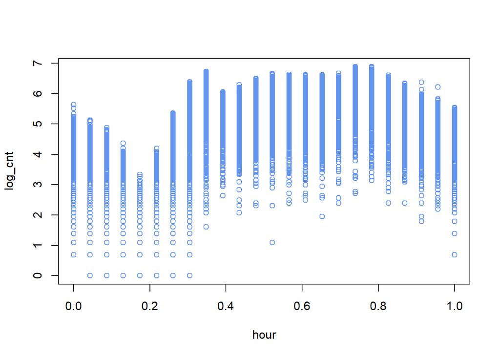

```r
bike_data$log_cnt <- log(bike_data$cnt) #create column log_cnt and attribute log of column cnt to it
bike_data$hour <- bike_data$hr/23 # transform [0, 23] to [0, 1] to make it more suitable for the algorithm. 0 is midnight, 1 is 11 PM
plot(log_cnt ~ hour, data = bike_data, col = "cornflowerblue")#Create a scatter plot by default
```

The number of rides seem to peak in the morning (8 AM $8/23 \approx 0.35$ ) and after work (6 PM $18/23 \approx 0.78$).

We start by fitting a polynomial of order 2 to a training dataset consisting of Feb 1, 2011 - March 31, 2011. We use the following two months (April 1, 2011 - May 31, 2011) as test dataset to evaluate the predictions. The following code creates the training and test datasets.

**Step 2: Create the training and test datasets**

```r
bike_data_train <- bike_data[bike_data$dteday >= as.Date("2011-02-01") & bike_data$dteday <=  as.Date("2011-03-31"), ]
bike_data_test <- bike_data[bike_data$dteday >= as.Date("2011-04-01") & bike_data$dteday <=  as.Date("2011-05-31"), ]
```

The following code estimates the model (a polynomial of order 2) using least squares and computes the root mean squared error (RMSE) for both the training data and the test data. Moreover, the code plots the training data, test data and the fitted polynomial in the same plot.

### Problem 1.1

Fit a polynomial of order 8 using least squares, without using R functions such as `lm()`. Plot the training data, test data and the fitted polynomial in the same plot.

**Step 3: Estimate the model using least squares method**

```r
y_train <- bike_data_train$log_cnt
y_test <- bike_data_test$log_cnt
p <- 8 # Order of polynomial

#Design matrix of features
x_train <- cbind(1, poly(bike_data_train$hour, p, raw = TRUE, simple = TRUE))

#Find coefficient
beta_hat <- solve(t(x_train)%*%x_train)%*%t(x_train)%*%y_train #t(x_train) = transpose of x_train

# Predict in-sample and compute RMSE
y_hat_train <- x_train%*%beta_hat
RMSE_train <- sqrt(sum((y_train - y_hat_train)^2)/length(y_train))
cat("RMSE_train", RMSE_train,"\n")
```

```
RMSE_train 0.7232024
```

```r
# Predict out_of_sample and compute RMSE
x_test <- cbind(1,poly(bike_data_test$hour, p, raw = TRUE, simple = TRUE))
y_hat_test <- x_test%*%beta_hat
RMSE_test <- sqrt(sum((y_test - y_hat_test)^2)/length(y_test))
cat("RMSE_test", RMSE_test,"\n")
```

```
RMSE_test 1.021449
```

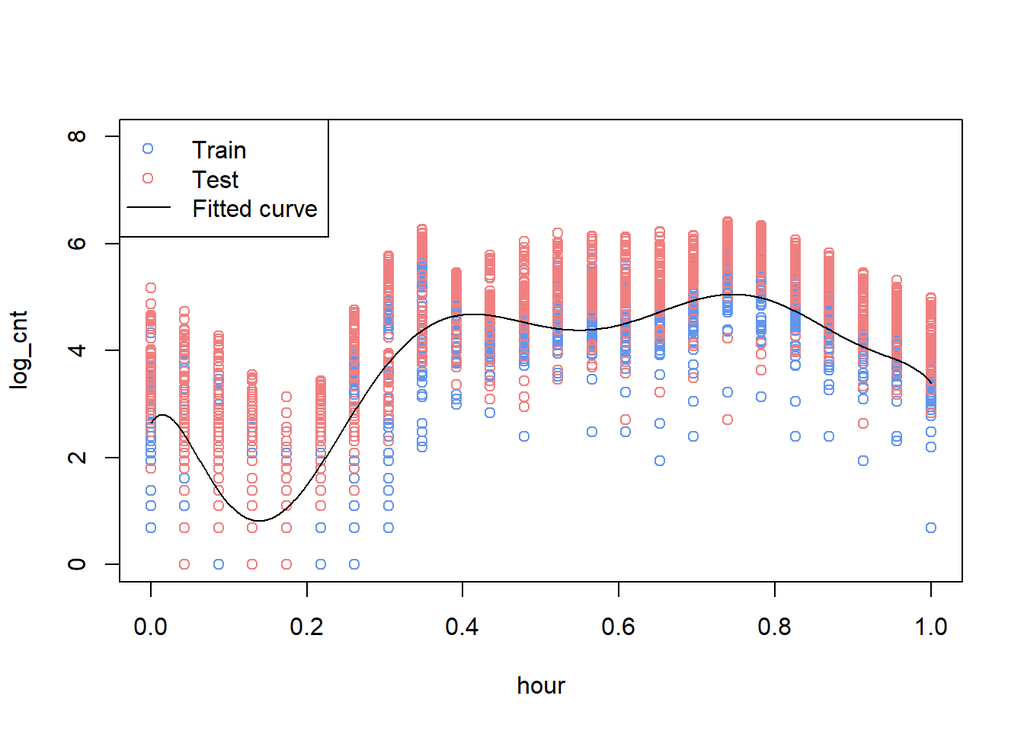

```r
# Plot training data, test data, and fit on a fine grid.
plot(log_cnt ~ hour, data = bike_data_train, col = "cornflowerblue", ylim = c(0, 8)) #create a scatterplot showing how log_cnt varies across hours based on the training data
lines(bike_data_test$hour, bike_data_test$log_cnt, type = "p", col = "lightcoral") #add a graph type p - point (scatter plot) to the existing scatterplot, based on test data
hours_grid <- seq(0, 1, length.out = 1000) #create 1000 points from 0-1, to feed into the line graph, to create a smoother curve
x_grid <- cbind(1, poly(hours_grid, p, raw = TRUE, simple = TRUE))
y_hat_grid <- x_grid%*%beta_hat
lines(hours_grid, y_hat_grid, lty = 1, col = "black") #fit the line
legend(x = "topleft", pch = c(1, 1, NA), lty = c(NA, NA, 1), col = c("cornflowerblue", "lightcoral",  "black"), legend=c("Train", "Test", "Fitted curve"))
```

### Problem 1.2

Fit polynomials of varying order 1-10 using least squares, without using R functions such as `lm()`. Compute the RMSEs for the training and test data and plot them on the same figure as a function of the polynomial order. Are you underfitting or overfitting the data?

To fit polynomials of varying order 1-10, we can use a loop for p.

```r
orders <- 1:10
RMSE_train_vec <- numeric(length(orders)) #create a vector to store RMSE_train
RMSE_test_vec <- numeric(length(orders))  #create a vector to store RMSE_test

for (p in orders) {
  # Predict in-sample
  x_train <- cbind(1, poly(bike_data_train$hour, p, raw = TRUE, simple = TRUE))
  beta_hat <- solve(t(x_train) %*% x_train) %*% t(x_train) %*% y_train
  y_hat_train <- x_train %*% beta_hat
  RMSE_train_vec[p] <- sqrt(mean((y_train - y_hat_train)^2))

  # Predict out_of_sample
  x_test <- cbind(1, poly(bike_data_test$hour, p, raw = TRUE, simple = TRUE))
  y_hat_test <- x_test %*% beta_hat
  RMSE_test_vec[p] <- sqrt(mean((y_test - y_hat_test)^2))
}

# This cat is different as I want to display the vector vertically
cat("RMSE_train_vec:\n")
```

```
RMSE_train_vec:
```

```r
for (val in RMSE_train_vec) {
  cat(val, "\n")
}
```

```
1.178476
0.9872309
0.9225993
0.8675218
0.7975209
0.7925395
0.7513291
0.7232024
0.7225747
0.7192728
```

```r
cat("RMSE_test_vec:\n")
```

```
RMSE_test_vec:
```

```r
for (val in RMSE_test_vec) {
  cat(val, "\n")
}
```

```
1.32375
1.208817
1.149316
1.116446
1.069621
1.06539
1.038872
1.021449
1.0219
1.021743
```

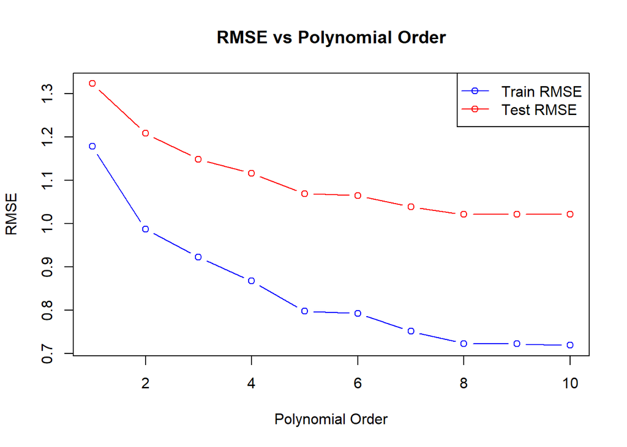

```r
# Plot RMSEs
plot(orders, RMSE_train_vec, type = "b", col = "blue", ylim = range(c(RMSE_train_vec, RMSE_test_vec)),
     xlab = "Polynomial Order", ylab = "RMSE", main = "RMSE vs Polynomial Order")
lines(orders, RMSE_test_vec, type = "b", col = "red")
legend("topright", legend = c("Train RMSE", "Test RMSE"), col = c("blue", "red"), lty = 1, pch = 1)
```

As the polynomial order increases, both training and test RMSE decrease, and the test RMSE eventually levels off. There is no clear sign of overfitting, since test RMSE does not increase at higher polynomial orders — it simply plateaus. This suggests that model complexity beyond a certain point brings diminishing returns, but not evident overfitting.

Overall, we have 3 scenarios:

- Underfitting: Both train and test loss function is high
- Good fit: Both train and test loss function is low
- Overfitting: Training loss is low/decreasing, while test loss is high/increasing, they may cross paths, and the test loss can decrease and then increase after 1 point (begins to overfit).

### Problem 1.3

Polynomials are global functions and their fit may be sensitive to outliers. Local fitting methods can sometimes be more robust (less affected by outliers). One such method is the loess method, which is a nonparametric method that fits locally weighted regressions to subsets of points and subsequently combines them to obtain a global fit. Use the loess function in R with the standard settings to fit a locally weighted regression to the training data. Is this method better than that in Problem 1.1? Plot the training data, test data and both fitted curves in the same plot.

The predict() function can be used on the object returned by loess().

```r
# Fit loess model to training data
loess_fit <- loess(log_cnt ~ hour, data = bike_data_train)

# Predict on training and test data
y_hat_loess_train <- predict(loess_fit, newdata = bike_data_train)
y_hat_loess_test <- predict(loess_fit, newdata = bike_data_test)

# Compute RMSE for loess
RMSE_loess_train <- sqrt(mean((bike_data_train$log_cnt - y_hat_loess_train)^2))
RMSE_loess_test <- sqrt(mean((bike_data_test$log_cnt - y_hat_loess_test)^2))

# COPY OF 1.1
y_train <- bike_data_train$log_cnt
y_test <- bike_data_test$log_cnt
p <- 8 # Order of polynomial

#Design matrix of features
x_train <- cbind(1, poly(bike_data_train$hour, p, raw = TRUE, simple = TRUE))

beta_hat <- solve(t(x_train)%*%x_train)%*%t(x_train)%*%y_train #Find coefficient, t(x_train) = transpose of x_train

plot(log_cnt ~ hour, data = bike_data_train, col = "cornflowerblue", ylim = c(0, 8)) #create a scatterplot showing how log_cnt varies across hours based on the training data
lines(bike_data_test$hour, bike_data_test$log_cnt, type = "p", col = "lightcoral") #add a graph type p - point (scatter plot) to the existing scatterplot, based on test data

# predict on a grid for a smooth curve
hours_grid <- seq(0, 1, length.out = 1000) #create 1000 points from 0-1, to feed into the line graph, to create a smoother curve
x_grid <- cbind(1, poly(hours_grid, p, raw = TRUE, simple = TRUE))
y_hat_grid <- x_grid%*%beta_hat
lines(hours_grid, y_hat_grid, lty = 1, col = "black") #fit the line
#END OF COPY

# For self-check
cat("RMSE_loess_train:", RMSE_loess_train, "\n")
```

```
RMSE_loess_train: 0.8989078
```

```r
cat("RMSE_loess_test:", RMSE_loess_test, "\n")
```

```
RMSE_loess_test: 1.120946
```

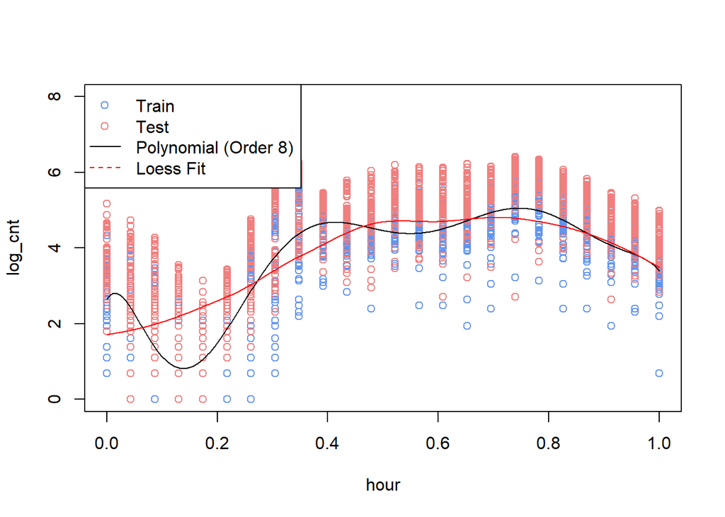

```r
# Plot loess fit on the same graph
loess_grid <- predict(loess_fit, newdata = data.frame(hour = hours_grid))
lines(hours_grid, loess_grid, col = "red", lty = 1)

legend("topleft", legend = c("Train", "Test", "Polynomial (Order 8)", "Loess Fit"), col = c("cornflowerblue", "lightcoral", "black", "red"), pch = c(1, 1, NA, NA), lty = c(NA, NA, 1, 2))
```

## 2. Regularised spline regression for bike rental data

Using the same training and test datasets as above, we will fit spline regressions with L1 and L2 regularisations (also known as penalties).

We create a natural cubic spline basis function for the variable hour with 25 equally spaced knots between 0.05 and 0.95. We first fit a regression using least squares without regularisation. The following code does this and plots the spline fit together with the training and test data. Note that we are not adding an intercept to the design matrix, since this is taken care of by the argument `intercept=TRUE`.

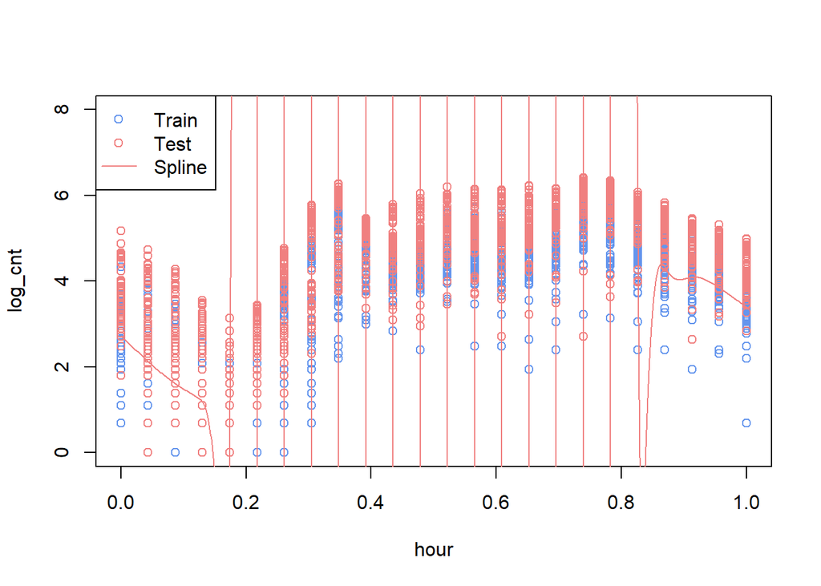

```r
suppressMessages(library(splines)) # Load the library splines
knots <- seq(0.05, 0.95, length.out = 25) # Creates 25 equally spaced knots between 0.05 and 0.95

x_train <- ns(bike_data_train$hour, knots = knots, intercept = TRUE) # Constructs natural cubic spline basis matrices for the hour variable in training data - ns creates splines basis
x_test <- ns(bike_data_test$hour, knots = knots, intercept = TRUE) # Constructs natural cubic spline basis matrices for the hour variable in test data
beta_hat <- solve(t(x_train)%*%x_train)%*%t(x_train)%*%y_train # Fits the spline regression using least squared

# Plot training data, test data, and spline fit on a fine grid (similar to problem 1, already explained)
plot(log_cnt ~ hour, data = bike_data_train, col = "cornflowerblue", ylim = c(0, 8))
lines(bike_data_test$hour, bike_data_test$log_cnt, type = "p", col = "lightcoral")
hours_grid <- seq(0, 1, length.out = 1000)
X_grid <- ns(hours_grid, knots = knots, intercept = TRUE) # cbind(1, ns(hours_grid, knots = knots))
y_hat_spline_grid <- X_grid%*%beta_hat
lines(hours_grid, y_hat_spline_grid, lty = 1, col = "lightcoral")
legend(x = "topleft", pch = c(1, 1, NA), lty = c(NA, NA, 1), col = c("cornflowerblue", "lightcoral",  "lightcoral"), legend=c("Train", "Test", "Spline"))
```

We have deliberately chosen too many knots and no regularisation so that the fit has a large variance, which is clearly evident from the figure above. Your task in the next problem is to fit a regularised spline regression.

### Problem 2.1

Fit a spline regression to the training data with an L2 regularisation using a suitable value of $\lambda$, without using R functions such as `glmnet()`. Plot the fit together with the training and test data.

**Tip**

The least squares estimator when using an L2 penalty is known as the Ridge regression estimator. Moreover, to determine a suitable value of $\lambda$, one approach is to fit several models (using different $\lambda$ values, e.g. `lambda_grid <- seq(0, 1, length.out=100)`) and choose the value of $\lambda$ that minimises the root mean squared error of the test data.

$\lambda >0$ is the regularization parameter, it controls how much we penalize large coefficients. To find a suitable value of $\lambda$ , we need to try out a bunch of them (100), and then find the lambda that gives the lowest RMSE. To do this, we can use a loop to try out those values

```r
# Create lambda values to try out
lambda_grid <- seq(0, 1, length.out=100)

# Create vectors to store RMSE values
RMSE_test <- numeric(length(lambda_grid))
RMSE_train <- numeric(length(lambda_grid))

#Create identity matrix with dimension = ncol in x_train
matrix_I <- diag(ncol(x_train))

# Loop over lambda values to compute ridge regression estimates and RMSEs
for (i in seq_along(lambda_grid)) # seq_along: Generates a sequence of integers from 1 to the length of lambda_grid
  {
  lambda <- lambda_grid[i]

  # Ridge regression estimator: (X'X + λI)^(-1) X'y
  beta_ridge <- solve(t(x_train) %*% x_train + lambda * matrix_I) %*% t(x_train) %*% y_train

  # Predict on train data
  y_hat_train <- x_train %*% beta_ridge
  RMSE_train[i] <- sqrt(mean((y_train - y_hat_train)^2))

  # Predict on test data
  y_hat_test <- x_test %*% beta_ridge
  RMSE_test[i] <- sqrt(mean((y_test - y_hat_test)^2))
}

# Find the lambda that gives the lowest RMSE
best_lambda <- lambda_grid[which.min(RMSE_test)] # which.min return index of the smallest RMSE in that vector

# Fit final model using best lambda
beta_ridge_best <- solve(t(x_train) %*% x_train + best_lambda * matrix_I) %*% t(x_train) %*% y_train

# For self-check
cat("best_lambda", best_lambda, "\n") # for self-check
```

```
best_lambda 0.01010101
```

```r
cat("min(RMSE_train)", min(RMSE_train), "\n")
```

```
min(RMSE_train) 0.6911984
```

```r
cat("min(RMSE_test)", min(RMSE_test), "\n")
```

```
min(RMSE_test) 1.006595
```

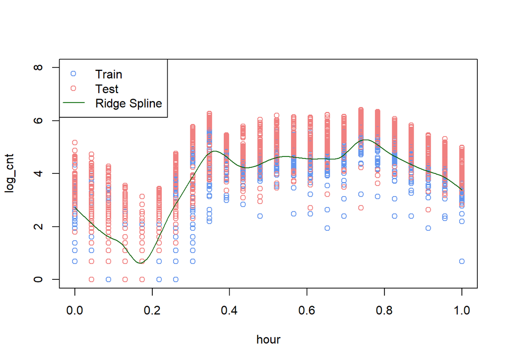

```r
# Plot training data, test data, and fitted spline curve
plot(log_cnt ~ hour, data = bike_data_train, col = "cornflowerblue", ylim = c(0, 8))
lines(bike_data_test$hour, bike_data_test$log_cnt, type = "p", col = "lightcoral")

# Predict on a fine grid for smooth curve
hours_grid <- seq(0, 1, length.out = 1000)
x_grid <- ns(hours_grid, knots = knots, intercept = TRUE)
y_hat_grid <- x_grid %*% beta_ridge_best

# Add fitted curve to plot
lines(hours_grid, y_hat_grid, lty = 1, col = "darkgreen")
legend(x = "topleft", pch = c(1, 1, NA), lty = c(NA, NA, 1),
       col = c("cornflowerblue", "lightcoral", "darkgreen"),
       legend = c("Train", "Test", "Ridge Spline"))
```

### Problem 2.2

Use the package `glmnet` to fit a spline regression with an L2 regularisation using the same basis functions as the previous problem. Find the optimal $\lambda$ by applying the one-standard deviation rule when cross-validating the training data using 10 folds. Compute the RMSE (using the optimal $\lambda$) for the training and test data. Plot the fit together with the training and test data.

**Tip**

The `help()` function will be very useful here. Another useful function is `cv.glmnet()`, where cv stands for cross-validation. The argument `alpha` (to the `cv.glmnet()` function) is key. Finally, the `predict()` function can be used on the object returned by `cv.glmnet()` and the argument `s` (to the `predict()` function) controls which $\lambda$ to use.

Both add a penalty term (controlled by λ), but the form of the penalty differs:

Closed-form solution: $\hat{\beta} = (X^\top X + \lambda I)^{-1} X^\top y$

L1 (Lasso) uses their *absolute value*, Forces some coefficients exactly to 0, Adds bias, but can simplify model by removing variables.

```r
suppressMessages(library(glmnet))
```

```r
# Fit ridge regression using cross-validation function in glmnet
set.seed(0)
cv_fit_L2 <- cv.glmnet(x_train, y_train, alpha = 0, nfolds = 10) #alpha = 0: L2 penalty only

#str(cv_fit_L2) # For self-check

# Extract optimal lambda using one-standard deviation rule
lambda_best_L2 <- cv_fit_L2$lambda.1se
#lambda.1se: The largest λ within one standard error of the minimum cross-validated error

# Predict in-sample using optimal lambda
y_hat_train <- predict(cv_fit_L2, newx = x_train, s = lambda_best_L2)
RMSE_train <- sqrt(mean((y_train - y_hat_train)^2))

# Predict out-of-sample using optimal lambda
y_hat_test <- predict(cv_fit_L2, newx = x_test, s = lambda_best_L2)
RMSE_test <- sqrt(mean((y_test - y_hat_test)^2))

cat("lambda_best_L2", lambda_best_L2, "\n")
```

```
lambda_best_L2 0.4378188
```

```r
cat("RMSE_train", RMSE_train, "\n")
```

```
RMSE_train 0.7111962
```

```r
cat("RMSE_test", RMSE_test, "\n")
```

```
RMSE_test 1.000773
```

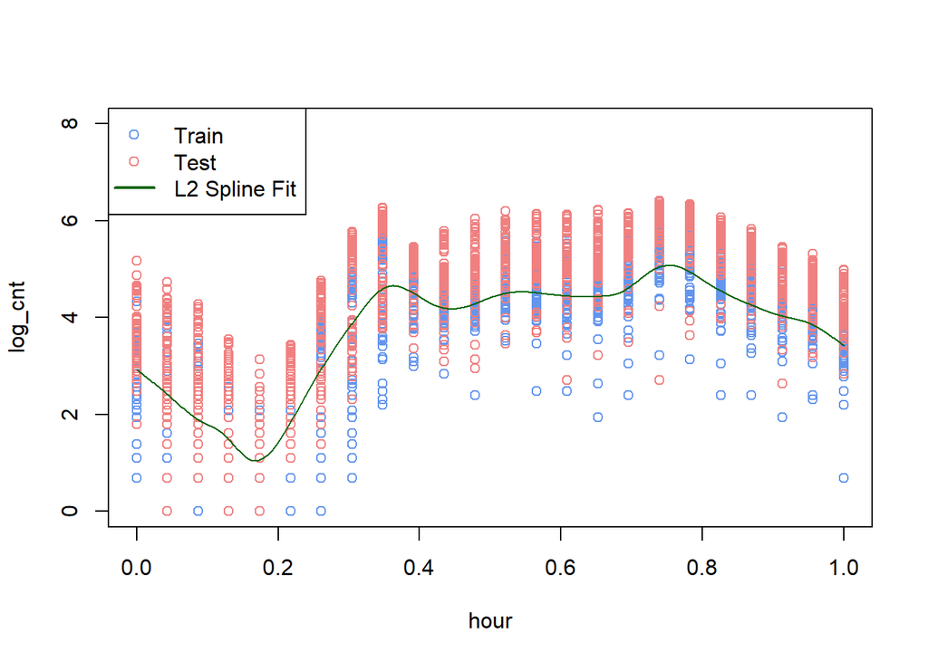

```r
# Plot training data, test data, and fitted spline curve
plot(log_cnt ~ hour, data = bike_data_train, col = "cornflowerblue", ylim = c(0, 8))
points(bike_data_test$hour, bike_data_test$log_cnt, col = "lightcoral")

# Create a fine grid for smooth curve
hours_grid <- seq(0, 1, length.out = 1000)
x_grid <- ns(hours_grid, knots = knots, intercept = TRUE)
y_hat_grid <- predict(cv_fit_L2, newx = x_grid, s = lambda_best_L2)

# Add fitted curve to plot
lines(hours_grid, y_hat_grid, col = "darkgreen", lwd = 1)

# Add legend
legend("topleft", legend = c("Train", "Test", "L2 Spline Fit"),
       col = c("cornflowerblue", "lightcoral", "darkgreen"),
       pch = c(1, 1, NA), lty = c(NA, NA, 1), lwd = c(NA, NA, 2))
```

### Problem 2.3

Repeat Problem 2.2, however, use the optimal $\lambda$ that minimises the mean cross-validated error. Compare the RMSE for the training and test data to those in Problem 2.2.

**Tip**

The `help()` function will be very useful here.

```r
# Use lambda that minimizes mean cross-validated error
lambda_min <- cv_fit_L2$lambda.min

# Predict in-sample using lambda_min
y_hat_train <- predict(cv_fit_L2, newx = x_train, s = lambda_min)
RMSE_train <- sqrt(mean((y_train - y_hat_train)^2))

# Predict out-of-sample using lambda_min
y_hat_test <- predict(cv_fit_L2, newx = x_test, s = lambda_min)
RMSE_test <- sqrt(mean((y_test - y_hat_test)^2))

cat("RMSE_train", RMSE_train, "\n")
```

```
RMSE_train 0.6919639
```

```r
cat("RMSE_test", RMSE_test, "\n")
```

```
RMSE_test 1.002668
```

```r
cat("lambda_min", lambda_min, "\n")
```

```
lambda_min 0.07475111
```

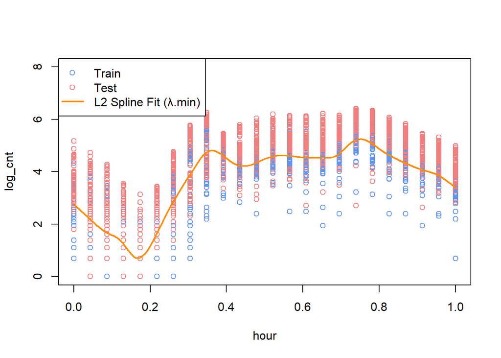

```r
# Plot training data, test data, and fitted spline curve
plot(log_cnt ~ hour, data = bike_data_train, col = "cornflowerblue", ylim = c(0, 8))
points(bike_data_test$hour, bike_data_test$log_cnt, col = "lightcoral")

# Generate predictions on a fine grid
hours_grid <- seq(0, 1, length.out = 1000)
x_grid <- ns(hours_grid, knots = knots, intercept = TRUE)
y_hat_grid <- predict(cv_fit_L2, newx = x_grid, s = lambda_min)

# Add fitted curve to plot
lines(hours_grid, y_hat_grid, col = "darkorange", lwd = 2)

# Add legend
legend("topleft", legend = c("Train", "Test", "L2 Spline Fit (λ.min)"),
       col = c("cornflowerblue", "lightcoral", "darkorange"),
       pch = c(1, 1, NA), lty = c(NA, NA, 1), lwd = c(NA, NA, 2))
```

[output not shown]

RMSE for train and test data in 2.2 and 2.3 are different, but by a very small gap. It’s safe to say they are similar. However, when choosing a model, using $\lambda$.1se is more simple, as it tends to include fewer features, due to more regularization.

### Problem 2.4

Repeat Problem 2.2 using L1 regularisation. Compare the RMSE for the training and test data to those in Problem 2.2.

**Tip**

The `help()` function will be very useful here to set the argument `alpha` (to the `cv.glmnet()` function).

```r
# Fit L1 regression using cross-validation
set.seed(0)
cv_fit_L1 <- cv.glmnet(x_train, y_train, alpha = 1, nfolds = 10)
#str(cv_fit_L1) #for self-check

# Extract best lambda
lambda_L1 <- cv_fit_L1$lambda.1se

# Predict in-sample using lambda_L1
y_hat_train <- predict(cv_fit_L1, newx = x_train, s = lambda_L1)
RMSE_train <- sqrt(mean((y_train - y_hat_train)^2))

# Predict out-of-sample using lambda_L1
y_hat_test <- predict(cv_fit_L1, newx = x_test, s = lambda_L1)
RMSE_test <- sqrt(mean((y_test - y_hat_test)^2))

# For self-check
cat("RMSE_train", RMSE_train, "\n") #for self-check
```

```
RMSE_train 0.7085636
```

```r
cat("RMSE_test", RMSE_test, "\n")
```

```
RMSE_test 1.003751
```

```r
cat("lambda_L1",lambda_L1, "\n")
```

```
lambda_L1 0.04179192
```

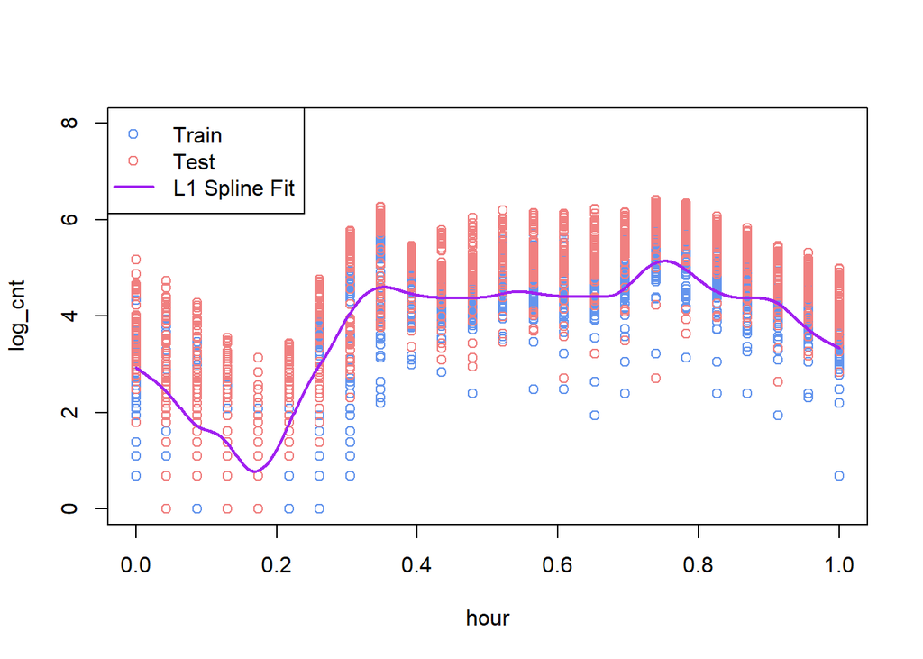

```r
# Plot training data, test data, and fitted spline curve
plot(log_cnt ~ hour, data = bike_data_train, col = "cornflowerblue", ylim = c(0, 8))
points(bike_data_test$hour, bike_data_test$log_cnt, col = "lightcoral")

# Generate predictions on a fine grid
hours_grid <- seq(0, 1, length.out = 1000)
x_grid <- ns(hours_grid, knots = knots, intercept = TRUE)
y_hat_grid <- predict(cv_fit_L1, newx = x_grid, s = lambda_L1)

# Add fitted curve to plot
lines(hours_grid, y_hat_grid, col = "purple", lwd = 2)

# Add legend
legend("topleft", legend = c("Train", "Test", "L1 Spline Fit"),
       col = c("cornflowerblue", "lightcoral", "purple"),
       pch = c(1, 1, NA), lty = c(NA, NA, 1), lwd = c(NA, NA, 2))
```

[output not shown]

The RMSE in 2.2 and 2.4 are comparable. As the number of features used in this case is low (1), L2 could be a better fit, as it shrink, but not drop any coefficients to 0.

## 3. Regularised regression for bike rental data with more features and data

We now consider the full dataset and use many more features. We use the first one and a half years (Jan 1, 2011 - May 31, 2012) of data for training and the last half year (June 1, 2012- Dec 31, 2012) for testing.

We will use the following categorical features:

- `weathersit`: Clear (1), cloudy (2), light rain (3), heavy rain (4).
- `weekday`: Sun (0), Mon (1), Tue (2), Wed (3), Thu (4), Fri (5), Sat (6).
- `season`: Winter (1), spring (2), summer (3), fall (4).

We will use the common approach in statistics that creates $K-1$ dummy variables for a categorical variable with $K$ levels. The first level is the reference category. The following code constructs these so called one-hot encodings and adds them to the dataset `bike_data`.

```r
# One hot for weathersit
one_hot_encode_weathersit <- model.matrix(~ as.factor(weathersit) - 1,data = bike_data) # create a matrix with one column per level of weathersit
one_hot_encode_weathersit  <- one_hot_encode_weathersit[, -1] # Remove reference category
colnames(one_hot_encode_weathersit) <- c('cloudy', 'light rain', 'heavy rain')
bike_data <- cbind(bike_data, one_hot_encode_weathersit) # Add the new dummy variables to the original bike_data dataframe.

# One hot for weekday
one_hot_encode_weekday <- model.matrix(~ as.factor(weekday) - 1,data = bike_data)
one_hot_encode_weekday  <- one_hot_encode_weekday[, -1] # Remove reference category
colnames(one_hot_encode_weekday) <- c('Mon', 'Tue', 'Wed', 'Thu', 'Fri', 'Sat')
bike_data <- cbind(bike_data, one_hot_encode_weekday)

# One hot for season
one_hot_encode_season <- model.matrix(~ as.factor(season) - 1,data = bike_data)
one_hot_encode_season  <- one_hot_encode_season[, -1] # Remove reference category
colnames(one_hot_encode_season) <- c('Spring', 'Summer', 'Fall')
bike_data <- cbind(bike_data, one_hot_encode_season)
```

```r
# Prepare the data sets
bike_data_train_3 <- bike_data[bike_data$dteday >= as.Date("2011-01-01") & bike_data$dteday <=  as.Date("2012-05-31"), ]
bike_data_test_3 <- bike_data[bike_data$dteday >= as.Date("2012-06-01") & bike_data$dteday <=  as.Date("2012-12-31"), ]
```

### Problem 3.1

Fit a spline regression to the training data with an L1 regularisation. Find the optimal $\lambda$ by applying the one-standard deviation rule when cross-validating the training data using 10 folds. Compute the RMSE (using the optimal $\lambda$) for the training and test data. For the spline, use the `splines` package in R to create natural cubic splines basis functions of the variable `hour` with 10 degrees of freedom, i.e. use the `ns()` function with df=10 as input argument. Moreover, set `intercept=FALSE` and add it manually to your design matrix instead.

The following variables should be included in the regression:

- Response variable: `log_cnt`.
- Features: `hour` (via the cubic spline described above), `yr`, `holiday`, `workingday`, `temp`, `atemp`, `hum`, `windspeed`, and all the dummy variables created above.

**Tip**

First create the design matrix of interest (you have to exclude the original variables you did the one-hot coding for). When creating the spline basis for the test data, you will need to use the same knots as when constructing the basis functions for the training dataset. If the spline is stored in a variable `spline_basis`, you can extract the knots by using `knots<-attr(spline_basis, "knots")` and then use the `knots` argument when constructing the design matrix for the test data, e.g. `ns(bike_all_data_test$hour, df=10, knots=knots, intercept = FALSE)`.

```r
y_train3 <- bike_data_train_3$log_cnt
y_test3 <- bike_data_test_3$log_cnt

# Construct natural cubic spline basis matrices for the hour variable in training data
x_train3_hour <- ns(bike_data_train_3$hour, df = 10, intercept = FALSE)
knots <- attr(x_train3_hour, "knots")
x_test3_hour <- ns(bike_data_test_3$hour, df = 10, knots = knots, intercept = FALSE)

# Construct design matrices (combine other features, including one-hotted ones)
x_train3 <- cbind(
  1,  # Manual intercept
  x_train3_hour,
  bike_data_train_3[c('yr', 'holiday', 'workingday', 'temp', 'atemp', 'hum', 'windspeed', 'Spring', 'Summer', 'Fall', 'Mon', 'Tue', 'Wed', 'Thu', 'Fri', 'Sat', 'cloudy', 'light rain', 'heavy rain')]
)

x_test3 <- cbind(
  1,
  x_test3_hour,
  bike_data_test_3[c('yr', 'holiday', 'workingday', 'temp', 'atemp', 'hum', 'windspeed', 'Spring', 'Summer', 'Fall', 'Mon', 'Tue', 'Wed', 'Thu', 'Fri', 'Sat', 'cloudy', 'light rain', 'heavy rain')]
)

# Fit L1 regression
set.seed(0)

cv_L1_3 <- cv.glmnet(as.matrix(x_train3), y_train3, alpha = 1, nfolds = 10, intercept = FALSE)

# Select lambda using one-standard deviation rule
lambda_1se <- cv_L1_3$lambda.1se
cat("lambda_1se", lambda_1se, "\n")
```

```
lambda_1se 0.01797346
```

```r
# Predict in-sample
y_hat3_train <- predict(cv_L1_3, newx = as.matrix(x_train3), s = lambda_1se)
RMSE_train <- sqrt(mean((y_train3 - y_hat3_train)^2))
cat("RMSE_train", RMSE_train, "\n")
```

```
RMSE_train 0.7284213
```

```r
# Predict out-of-sample
y_hat3_test <- predict(cv_L1_3, newx = as.matrix(x_test3), s = lambda_1se)
RMSE_test <- sqrt(mean((y_test3 - y_hat3_test)^2))
cat("RMSE test", RMSE_test, "\n")
```

```
RMSE test 0.7113729
```

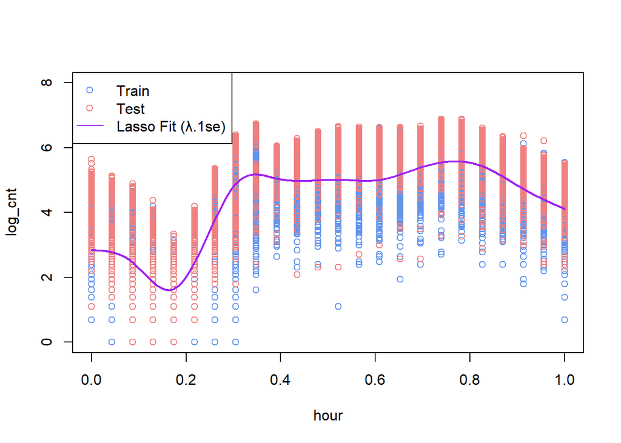

```r
# Predict on grid for plotting
hours_grid <- seq(0, 1, length.out = 1000)
hour_spline_grid <- ns(hours_grid, df = 10, knots = knots, intercept = FALSE)

# Create dummy feature matrix for plotting (use average values)
x_grid <- cbind(
  1,
  hour_spline_grid,
  matrix(colMeans(x_train3[, -c(1:11)]), nrow = 1000, ncol = ncol(x_train3) - 11, byrow = TRUE)
)

y_hat_grid <- predict(cv_L1_3, newx = x_grid, s = lambda_1se)

# Plot
plot(log_cnt ~ hour, data = bike_data_train_3, col = "cornflowerblue", ylim = c(0, 8))
points(bike_data_test_3$hour, bike_data_test_3$log_cnt, col = "lightcoral")
lines(hours_grid, y_hat_grid, col = "purple", lwd = 2)
legend("topleft", legend = c("Train", "Test", "Lasso Fit (λ.1se)"),
       col = c("cornflowerblue", "lightcoral", "purple"), pch = c(1, 1, NA), lty = c(NA, NA, 1))
```

### Problem 3.2

Which three features in Problem 3.1 seem to be the most important?

**Tip**

To explore which variables are most important, you can re-estimate the model in Problem 3.1 without cross-validation (using `glmnet()`). Note that you can apply the `plot()` function to an object returned by `glmnet()` using the arguments `xvar="lambda"` or `xvar="norm"`, and `label="TRUE"`, which allows you to visualise the lasso path.

To decide which features are more important, we can look at coefficient paths to see which become non-zero first

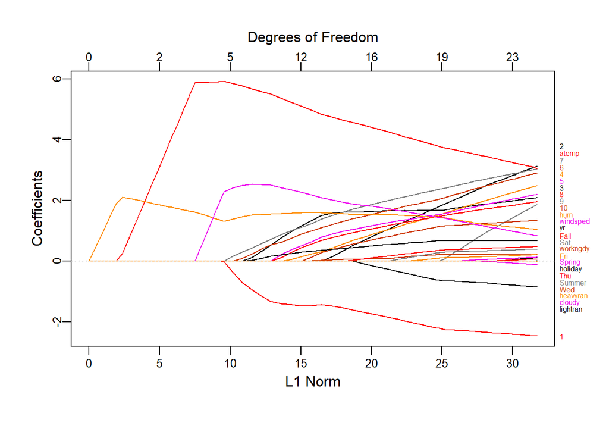

```r
library(plotmo)
set.seed(0)
# Fit L1 model without CV
L1_without_CV <- glmnet(as.matrix(x_train3), y_train3, alpha = 1, intercept = FALSE)

# Plot coefficient paths as lambda changes = how each feature’s coefficient changes as the regularisation strength (λ) varies
plot_glmnet(L1_without_CV, xvar = "norm", label = TRUE)
```

```r
# Extract the name of top 3 features
coef_mat <- as.matrix(L1_without_CV$beta) #create matrix of all coefficients
first_nonzero_index <- apply(coef_mat, 1, function(row) which(row != 0)[1]) # look through each row of coef_mat, grab the index of the first non-zero beta
# Sort features by when they first become non-zero
sorted_features <- sort(first_nonzero_index, na.last = NA)  # remove features that never enter

# Get the names of the top 3 earliest features
top3_early_features <- names(sorted_features)[1:3]
print(top3_early_features)
```

```
[1] "hum"       "atemp"     "windspeed"
```

### Problem 3.3

Carry out a residual analysis in Problem 3.1 for the training data. What can you say about the assumption of independent residuals? Repeat the same for the test data.

**Tip**

Plot the autocorrelation function of the residuals to validate the independence assumption.

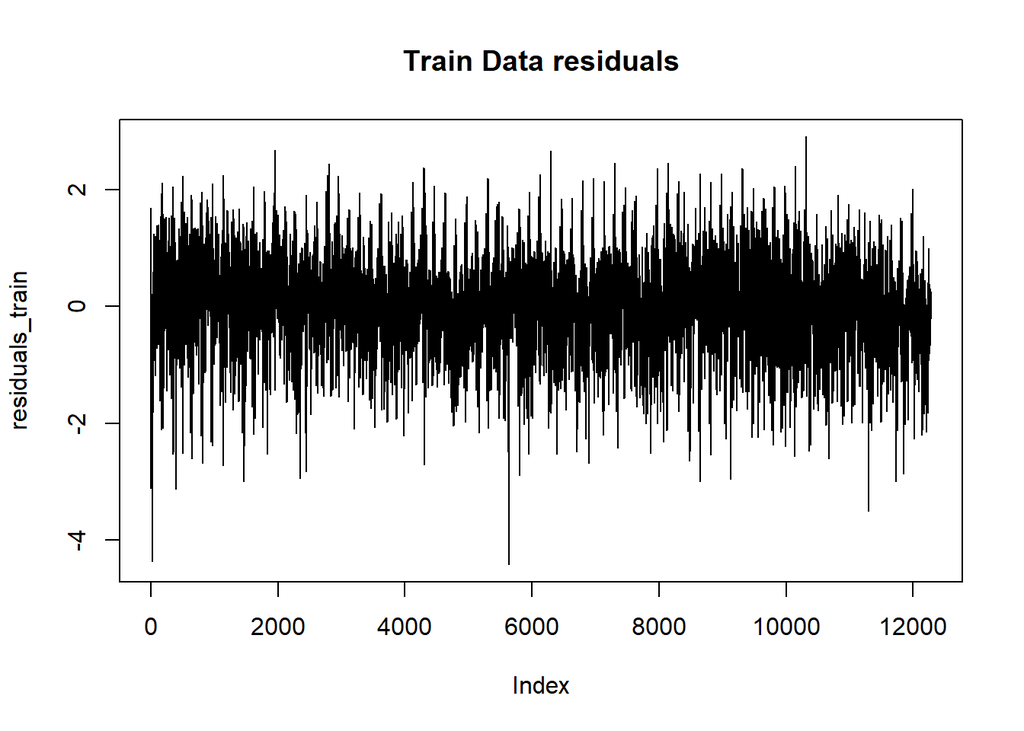

```r
# Compute the residuals for train and test data
residuals_train <- y_train3 - y_hat3_train
residuals_test <- y_test3 - y_hat3_test

# Plot residuals on train and test dataa
plot(residuals_train, type = "l", main = "Train Data residuals")
```

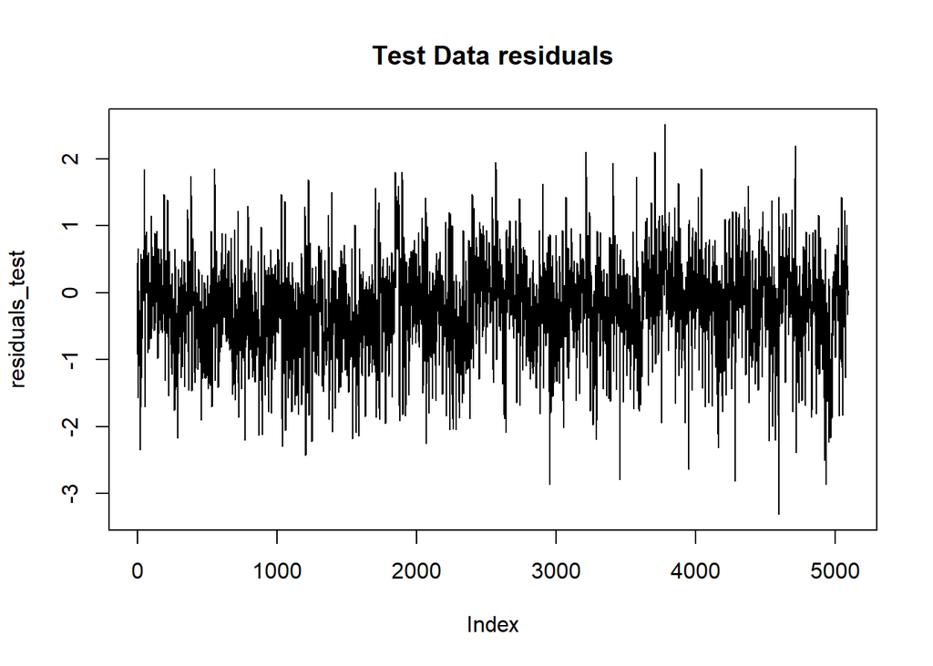

```r
plot(residuals_test, type = "l", main = "Test Data residuals")
```

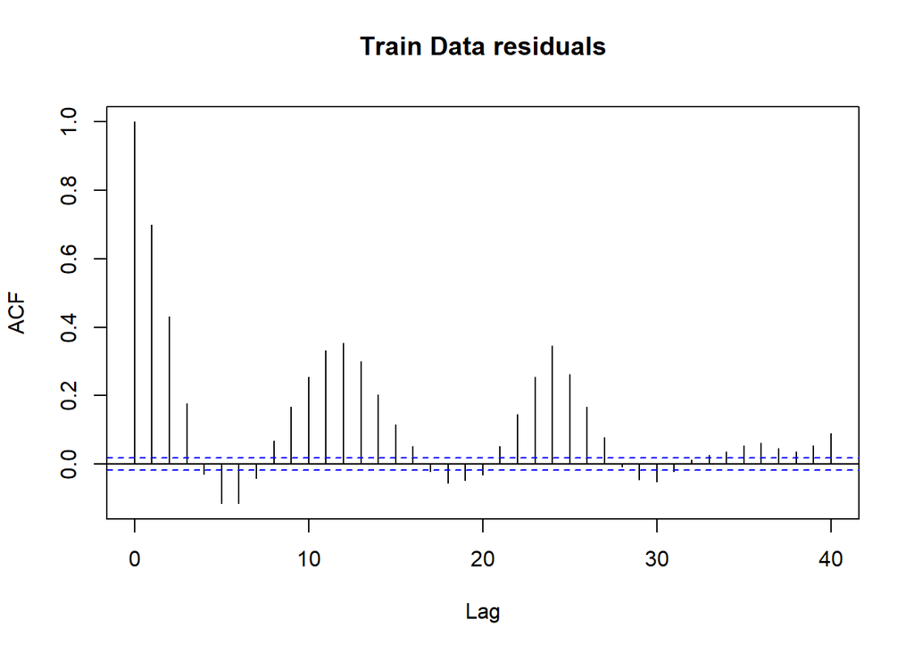

```r
# Plot acf
acf(residuals_train, main = "Train Data residuals")
```

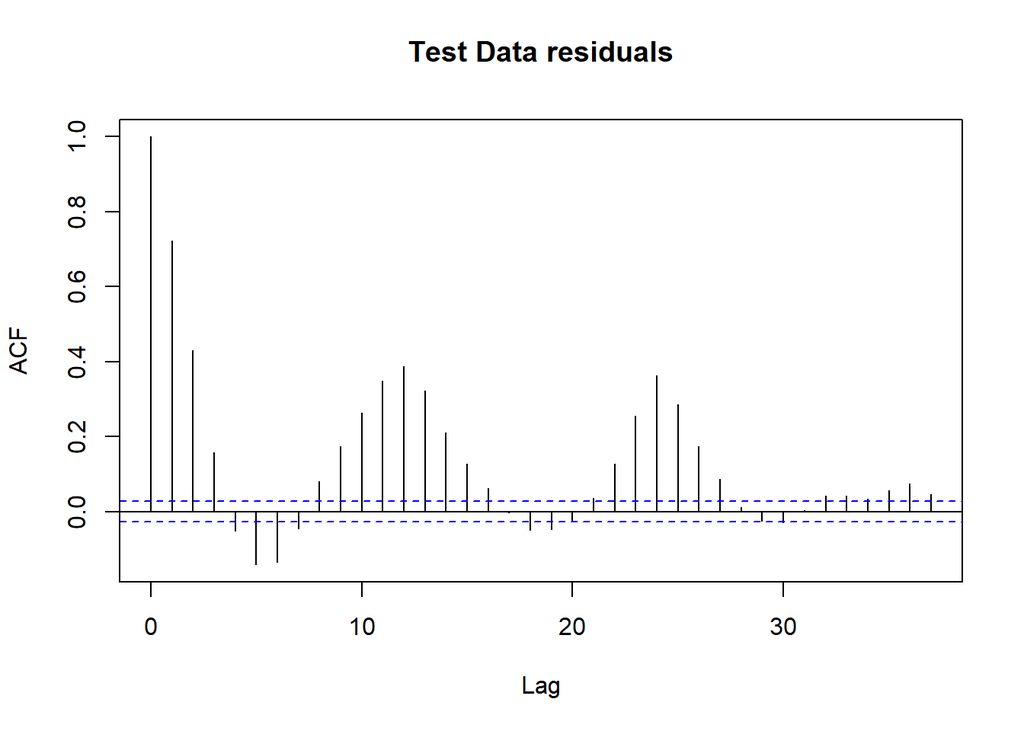

```r
acf(residuals_test, main = "Test Data residuals")
```

From the plots of acf for both train and test data, we can see that acf spikes far out of the threshold levels (represent the approximate **95% confidence interval** under the null hypothesis that the data is uncorrelated) in the first 30 lags, which indicate the strong correlation between past and future data. Therefore, the assumption of independent residuals is wrong.

If all bars stay within the dashed lines, the series shows no significant autocorrelation in that lag.

## 4. Regularised time series regression and regression trees for bike rental data

In this section we will consider the time series nature of the data.

### Problem 4.1

Plot a time series plot of the response in the original scale (i.e. counts and not log-counts) for the last week of the test data (last $24\times 7$ observations). In the same figure, plot a time series plot of the fitted values (in the original scale) from Problem 3.1. Comment on the fit.

```r
# Prepare the last week of test data
last_week_data <- tail(bike_data, n= 168)
str(last_week_data)
```

```
'data.frame':   168 obs. of  31 variables:
 $ instant   : int  17212 17213 17214 17215 17216 17217 17218 17219 17220 17221 ...
 $ dteday    : chr  "2012-12-24" "2012-12-25" "2012-12-25" "2012-12-25" ...
 $ season    : int  1 1 1 1 1 1 1 1 1 1 ...
 $ yr        : int  1 1 1 1 1 1 1 1 1 1 ...
 $ mnth      : int  12 12 12 12 12 12 12 12 12 12 ...
 $ hr        : int  23 0 1 2 4 5 6 7 8 9 ...
 $ holiday   : int  0 1 1 1 1 1 1 1 1 1 ...
 $ weekday   : int  1 2 2 2 2 2 2 2 2 2 ...
 $ workingday: int  1 0 0 0 0 0 0 0 0 0 ...
 $ weathersit: int  3 3 2 2 2 2 2 2 2 2 ...
 $ temp      : num  0.24 0.24 0.26 0.26 0.24 0.22 0.22 0.22 0.24 0.24 ...
 $ atemp     : num  0.288 0.258 0.258 0.258 0.258 ...
 $ hum       : num  0.93 0.93 0.87 0.87 0.87 0.93 0.93 0.93 0.87 0.87 ...
 $ windspeed : num  0 0.0896 0.1642 0.1642 0.0896 ...
```

[output cut: 17 more lines]

```r
head(last_week_data)
```

```
      instant     dteday season yr mnth hr holiday weekday workingday
17212   17212 2012-12-24      1  1   12 23       0       1          1
17213   17213 2012-12-25      1  1   12  0       1       2          0
17214   17214 2012-12-25      1  1   12  1       1       2          0
17215   17215 2012-12-25      1  1   12  2       1       2          0
17216   17216 2012-12-25      1  1   12  4       1       2          0
17217   17217 2012-12-25      1  1   12  5       1       2          0
      weathersit temp  atemp  hum windspeed casual registered cnt  log_cnt
17212          3 0.24 0.2879 0.93    0.0000      1         10  11 2.397895
17213          3 0.24 0.2576 0.93    0.0896      3         10  13 2.564949
17214          2 0.26 0.2576 0.87    0.1642      0         13  13 2.564949
17215          2 0.26 0.2576 0.87    0.1642      0          7   7 1.945910
17216          2 0.24 0.2576 0.87    0.0896      0          1   1 0.000000
17217          2 0.22 0.2273 0.93    0.1343      2          1   3 1.098612
            hour cloudy light rain heavy rain Mon Tue Wed Thu Fri Sat Spring
17212 1.00000000      0          1          0   1   0   0   0   0   0      0
17213 0.00000000      0          1          0   0   1   0   0   0   0      0
17214 0.04347826      1          0          0   0   1   0   0   0   0      0
17215 0.08695652      1          0          0   0   1   0   0   0   0      0
17216 0.17391304      1          0          0   0   1   0   0   0   0      0
17217 0.21739130      1          0          0   0   1   0   0   0   0      0
      Summer Fall
17212      0    0
17213      0    0
17214      0    0
17215      0    0
17216      0    0
17217      0    0
```

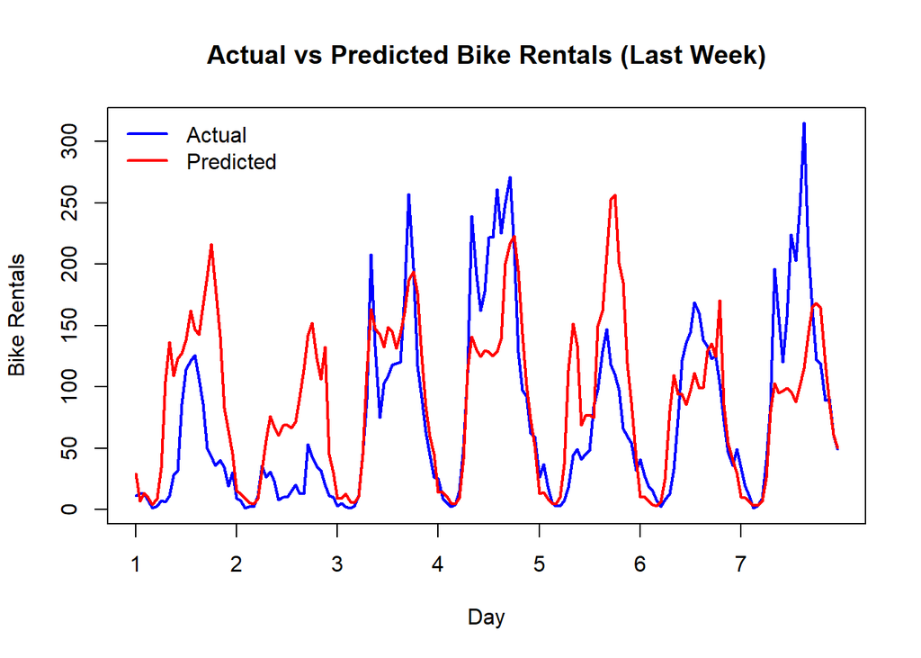

```r
# Plot actual data without x-axis
plot(last_week_data$cnt, type = "l", col = "blue", lwd = 2,
     ylab = "Bike Rentals", xlab = "Day", xaxt = "n",
     main = "Actual vs Predicted Bike Rentals (Last Week)")

# Add predicted values
y_hat_log = tail(y_hat3_test, n = 168)
y_hat_cnt = exp(y_hat_log)
lines(y_hat_cnt, col = "red", lwd = 2)

# Custom x-axis: mark each day
day_ticks <- seq(1, 168, by = 24)           # positions for each day
day_labels <- paste(1:7)                # labels
axis(1, at = day_ticks, labels = day_labels)   # add x-axis

# Add legends
legend("topleft", legend = c("Actual", "Predicted"),
       col = c("blue", "red"), lwd = 2, bty = "n")
```

The model can follow the overall trends of the actual data. However, it fails to capture extreme changes, such as big dips or sharp peaks. The model seems to predict “average” patterns (seasonal patterns) well.

### Problem 4.2

Add time series effects to your model by including some lagged values of the response as features. Use the first four hourly lags of `log_cnt` plus the 24th hourly lag as features, in addition to all other features in Problem 3.1. Fit the model using an L1 regularisation and find the optimal $\lambda$ by applying the one-standard deviation rule when cross-validating the training data using 10 folds. Compute the RMSE (using the optimal $\lambda$) for the training and test data and compare to Problem 3.1. Are the residuals from this new model more adequate?

**Tip**

The function `mutate()` from the `dplyr` package is useful for adding columns to a data frame. Moreover, the function `lags(x, k)` lags the time series `x` by `k` steps.

Notice that some observations are lost when lagging, i.e. `NA` values are introduced. You can remove these observations from the dataset.

```r
# Load dplyr library
library(dplyr)
```

```r
# Create lag features
bike_data <- bike_data %>%
  mutate(
    lag1 = lag(log_cnt, 1),
    lag2 = lag(log_cnt, 2),
    lag3 = lag(log_cnt, 3),
    lag4 = lag(log_cnt, 4),
    lag24 = lag(log_cnt, 24)
  )

# Drop NA rows
bike_data <- na.omit(bike_data)
str(bike_data)
```

```
'data.frame':   17355 obs. of  36 variables:
 $ instant   : int  25 26 27 28 29 30 31 32 33 34 ...
 $ dteday    : chr  "2011-01-02" "2011-01-02" "2011-01-02" "2011-01-02" ...
 $ season    : int  1 1 1 1 1 1 1 1 1 1 ...
 $ yr        : int  0 0 0 0 0 0 0 0 0 0 ...
 $ mnth      : int  1 1 1 1 1 1 1 1 1 1 ...
 $ hr        : int  0 1 2 3 4 6 7 8 9 10 ...
 $ holiday   : int  0 0 0 0 0 0 0 0 0 0 ...
 $ weekday   : int  0 0 0 0 0 0 0 0 0 0 ...
 $ workingday: int  0 0 0 0 0 0 0 0 0 0 ...
 $ weathersit: int  2 2 2 2 2 3 2 3 2 2 ...
 $ temp      : num  0.46 0.44 0.42 0.46 0.46 0.42 0.4 0.4 0.38 0.36 ...
 $ atemp     : num  0.455 0.439 0.424 0.455 0.455 ...
 $ hum       : num  0.88 0.94 1 0.94 0.94 0.77 0.76 0.71 0.76 0.81 ...
 $ windspeed : num  0.298 0.254 0.284 0.194 0.194 ...
```

[output cut: 24 more lines]

```r
head(bike_data)
```

```
   instant     dteday season yr mnth hr holiday weekday workingday weathersit
25      25 2011-01-02      1  0    1  0       0       0          0          2
26      26 2011-01-02      1  0    1  1       0       0          0          2
27      27 2011-01-02      1  0    1  2       0       0          0          2
28      28 2011-01-02      1  0    1  3       0       0          0          2
29      29 2011-01-02      1  0    1  4       0       0          0          2
30      30 2011-01-02      1  0    1  6       0       0          0          3
   temp  atemp  hum windspeed casual registered cnt   log_cnt       hour cloudy
25 0.46 0.4545 0.88    0.2985      4         13  17 2.8332133 0.00000000      1
26 0.44 0.4394 0.94    0.2537      1         16  17 2.8332133 0.04347826      1
27 0.42 0.4242 1.00    0.2836      1          8   9 2.1972246 0.08695652      1
28 0.46 0.4545 0.94    0.1940      2          4   6 1.7917595 0.13043478      1
29 0.46 0.4545 0.94    0.1940      2          1   3 1.0986123 0.17391304      1
30 0.42 0.4242 0.77    0.2985      0          2   2 0.6931472 0.26086957      0
   light rain heavy rain Mon Tue Wed Thu Fri Sat Spring Summer Fall     lag1
25          0          0   0   0   0   0   0   0      0      0    0 3.663562
26          0          0   0   0   0   0   0   0      0      0    0 2.833213
27          0          0   0   0   0   0   0   0      0      0    0 2.833213
28          0          0   0   0   0   0   0   0      0      0    0 2.197225
29          0          0   0   0   0   0   0   0      0      0    0 1.791759
30          1          0   0   0   0   0   0   0      0      0    0 1.098612
       lag2     lag3     lag4    lag24
25 3.332205 3.526361 3.583519 2.772589
26 3.663562 3.332205 3.526361 3.688879
27 2.833213 3.663562 3.332205 3.465736
28 2.833213 2.833213 3.663562 2.564949
29 2.197225 2.833213 2.833213 0.000000
30 1.791759 2.197225 2.833213 0.000000
```

```r
# Prepare data sets
bike_train_4.2 <- bike_data[bike_data$dteday >= as.Date("2011-01-01") & bike_data$dteday <= as.Date("2012-05-31"), ]
bike_test_4.2 <- bike_data[bike_data$dteday >= as.Date("2012-06-01") & bike_data$dteday <= as.Date("2012-12-31"), ]
head(bike_test_4.2)
```

```
      instant     dteday season yr mnth hr holiday weekday workingday
12284   12284 2012-06-01      2  1    6  0       0       5          1
12285   12285 2012-06-01      2  1    6  1       0       5          1
12286   12286 2012-06-01      2  1    6  2       0       5          1
12287   12287 2012-06-01      2  1    6  3       0       5          1
12288   12288 2012-06-01      2  1    6  4       0       5          1
12289   12289 2012-06-01      2  1    6  5       0       5          1
      weathersit temp  atemp  hum windspeed casual registered cnt  log_cnt
12284          1 0.66 0.6212 0.50    0.2537     10         76  86 4.454347
12285          1 0.64 0.6212 0.53    0.2239      0         34  34 3.526361
12286          1 0.64 0.6212 0.57    0.2239      3         13  16 2.772589
12287          2 0.62 0.5909 0.73    0.0896      0          4   4 1.386294
12288          2 0.62 0.5909 0.73    0.0896      1          5   6 1.791759
12289          2 0.62 0.5909 0.78    0.0896      4         41  45 3.806662
            hour cloudy light rain heavy rain Mon Tue Wed Thu Fri Sat Spring
12284 0.00000000      0          0          0   0   0   0   0   1   0      1
12285 0.04347826      0          0          0   0   0   0   0   1   0      1
12286 0.08695652      0          0          0   0   0   0   0   1   0      1
12287 0.13043478      1          0          0   0   0   0   0   1   0      1
12288 0.17391304      1          0          0   0   0   0   0   1   0      1
12289 0.21739130      1          0          0   0   0   0   0   1   0      1
      Summer Fall     lag1     lag2     lag3     lag4    lag24
12284      0    0 4.941642 5.575949 5.883322 6.171701 4.110874
12285      0    0 4.454347 4.941642 5.575949 5.883322 3.258097
12286      0    0 3.526361 4.454347 4.941642 5.575949 2.639057
12287      0    0 2.772589 3.526361 4.454347 4.941642 2.079442
12288      0    0 1.386294 2.772589 3.526361 4.454347 2.079442
12289      0    0 1.791759 1.386294 2.772589 3.526361 3.496508
```

```r
head(bike_train_4.2)
```

```
   instant     dteday season yr mnth hr holiday weekday workingday weathersit
25      25 2011-01-02      1  0    1  0       0       0          0          2
26      26 2011-01-02      1  0    1  1       0       0          0          2
27      27 2011-01-02      1  0    1  2       0       0          0          2
28      28 2011-01-02      1  0    1  3       0       0          0          2
29      29 2011-01-02      1  0    1  4       0       0          0          2
30      30 2011-01-02      1  0    1  6       0       0          0          3
   temp  atemp  hum windspeed casual registered cnt   log_cnt       hour cloudy
25 0.46 0.4545 0.88    0.2985      4         13  17 2.8332133 0.00000000      1
26 0.44 0.4394 0.94    0.2537      1         16  17 2.8332133 0.04347826      1
27 0.42 0.4242 1.00    0.2836      1          8   9 2.1972246 0.08695652      1
28 0.46 0.4545 0.94    0.1940      2          4   6 1.7917595 0.13043478      1
29 0.46 0.4545 0.94    0.1940      2          1   3 1.0986123 0.17391304      1
30 0.42 0.4242 0.77    0.2985      0          2   2 0.6931472 0.26086957      0
   light rain heavy rain Mon Tue Wed Thu Fri Sat Spring Summer Fall     lag1
25          0          0   0   0   0   0   0   0      0      0    0 3.663562
26          0          0   0   0   0   0   0   0      0      0    0 2.833213
27          0          0   0   0   0   0   0   0      0      0    0 2.833213
28          0          0   0   0   0   0   0   0      0      0    0 2.197225
29          0          0   0   0   0   0   0   0      0      0    0 1.791759
30          1          0   0   0   0   0   0   0      0      0    0 1.098612
       lag2     lag3     lag4    lag24
25 3.332205 3.526361 3.583519 2.772589
26 3.663562 3.332205 3.526361 3.688879
27 2.833213 3.663562 3.332205 3.465736
28 2.833213 2.833213 3.663562 2.564949
29 2.197225 2.833213 2.833213 0.000000
30 1.791759 2.197225 2.833213 0.000000
```

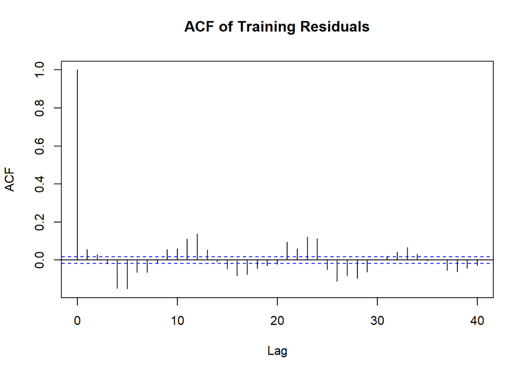

```r
y_train <- bike_train_4.2$log_cnt
y_test <- bike_test_4.2$log_cnt

# Spline for hours
spline_train <- ns(bike_train_4.2$hour, df = 10, intercept = FALSE)
knots <- attr(spline_train, "knots")
spline_test <- ns(bike_test_4.2$hour, df = 10, knots = knots, intercept = FALSE)

# Design matrices
x_train <- cbind(
  1,
  spline_train,
  bike_train_4.2[, c("yr", "holiday", "workingday", "temp", "atemp", "hum", "windspeed",
                 "Spring", "Summer", "Fall", "Mon", "Tue", "Wed", "Thu", "Fri", "Sat",
                 "cloudy", "light rain", "heavy rain",
                 "lag1", "lag2", "lag3", "lag4", "lag24")]
)

x_test <- cbind(
  1,
  spline_test,
  bike_test_4.2[, c("yr", "holiday", "workingday", "temp", "atemp", "hum", "windspeed",
                "Spring", "Summer", "Fall", "Mon", "Tue", "Wed", "Thu", "Fri", "Sat",
                "cloudy", "light rain", "heavy rain",
                "lag1", "lag2", "lag3", "lag4", "lag24")]
)

# Fit L1
set.seed(0)
cv_L1_4 <- cv.glmnet(as.matrix(x_train), y_train, alpha = 1, nfolds = 10, intercept = FALSE)
lambda_best <- cv_L1_4$lambda.1se

# Predict in-sample
y_hat_train <- predict(cv_L1_4, newx = as.matrix(x_train), s = lambda_best)
RMSE_train <- sqrt(mean((y_train - y_hat_train)^2))
residuals_train <- y_train - y_hat_train
acf(residuals_train, main = "ACF of Training Residuals")
```

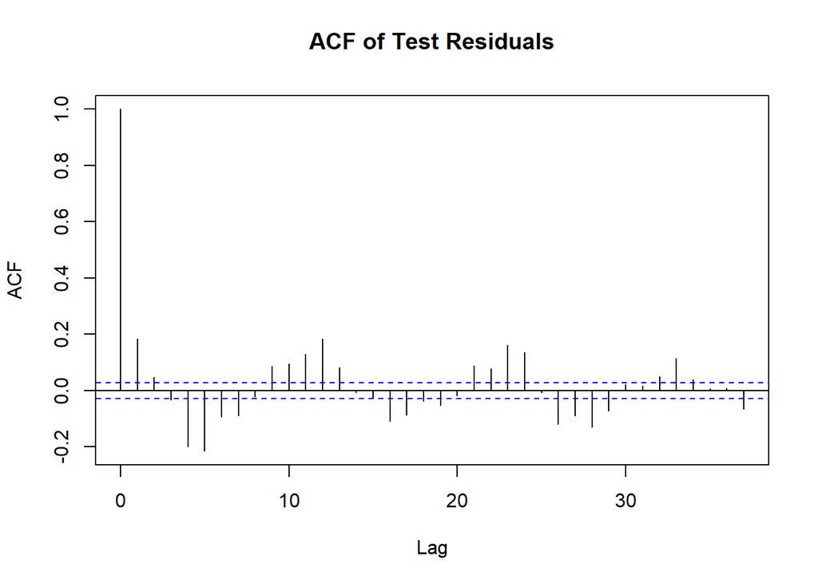

```r
# Predict out-of-sample
y_hat_test <- predict(cv_L1_4, newx = as.matrix(x_test), s = lambda_best)
RMSE_test <- sqrt(mean((y_test - y_hat_test)^2))
residuals_test <- y_test - y_hat_test
acf(residuals_test, main = "ACF of Test Residuals")
```

```r
cat("RMSE_train:", RMSE_train, "\n")
```

```
RMSE_train: 0.4360592
```

```r
cat("RMSE_test:", RMSE_test, "\n")
```

```
RMSE_test: 0.3732618
```

```r
cat("lambda_best:", lambda_best, "\n")
```

```
lambda_best: 0.007612828
```

```
Problem 3.1 RMSE_train 0.7284213   RMSE test 0.7113729
Problem 4.2 RMSE_train: 0.4360592  RMSE_test: 0.3732618
```

Based on RMSE and the shape of ACF plots, the model in 4.2 perform significantly better than 3.1’s. As the volume of the spikes in ACF of 4.2 is much lower, and closer to the thresholds, and it’s RMSE in both train and test data is only around half of that in 3.1.

### Problem 4.3

Add the predictions from Problem 4.2 to the figure you created in Problem 4.1. Did the predictions improve by adding lags of the response variable?

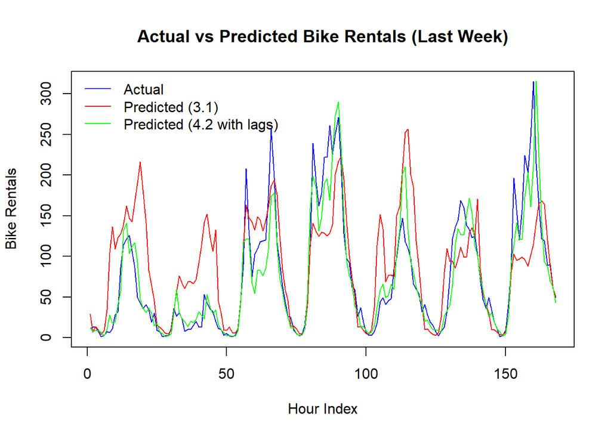

```r
# Extract the last week of predictions from Problem 4.2
y_hat_log_4.2 <- tail(y_hat_test, n = 168)
y_hat_cnt_4.2 <- exp(y_hat_log_4.2)

# COPY FROM 4.1
last_week_plot <- plot(last_week_data$cnt, type = "l", col = "blue", lwd = 1,
     ylab = "Bike Rentals", xlab = "Hour Index", main = "Actual vs Predicted Bike Rentals (Last Week)")
lines(y_hat_cnt, col = "red", lwd = 1)
# END OF COPY

# Add to existing plot
lines(y_hat_cnt_4.2, col = "green", lwd = 1)

# Update legend
legend("topleft", legend = c("Actual", "Predicted (3.1)", "Predicted (4.2 with lags)"),
       col = c("blue", "red", "green"), lwd = 1, bty = "n")
```

The model in 4.2 follows the actual line much closer, compared to the 3.1 model. It has successfully predicted most highs and lows, especially improved at extreme points.

### Problem 4.4

Another alternative to the semi-parametric approach above is to fit a regression tree.

Using the training dataset from Problem 4.2 (that also includes lagged values of the response as features), fit a regression tree using the `tree` package. If you want, experiment with the settings to see how changing them affects the results.

```r
library(tree)
```

```r
#Creates a data frame with the response variable log_cnt and all predictors from x_train. This is required because tree() expects a formula interface or a data frame.
bike_train_4.2 <- data.frame(
  log_cnt = y_train,
  x_train
)
bike_test_4.2 <- data.frame(
  log_cnt = y_test,
  x_test
)
```

```r
# Fit tree model
set.seed(0)
tree_model <- tree(log_cnt ~ ., data = bike_train_4.2)

y_hat_tree_train <- predict(tree_model, newdata = bike_train_4.2)
y_hat_tree_test <- predict(tree_model, newdata = bike_test_4.2)

RMSE_tree_train <- sqrt(mean((y_train - y_hat_tree_train)^2))
RMSE_tree_test <- sqrt(mean((y_test - y_hat_tree_test)^2))

cat("RMSE (Train):", RMSE_tree_train, "\n")
```

```
RMSE (Train): 0.5706015
```

```r
cat("RMSE (Test):", RMSE_tree_test, "\n")
```

```
RMSE (Test): 0.6000504
```

### Problem 4.5

Plot the tree structure in Problem 4.4.

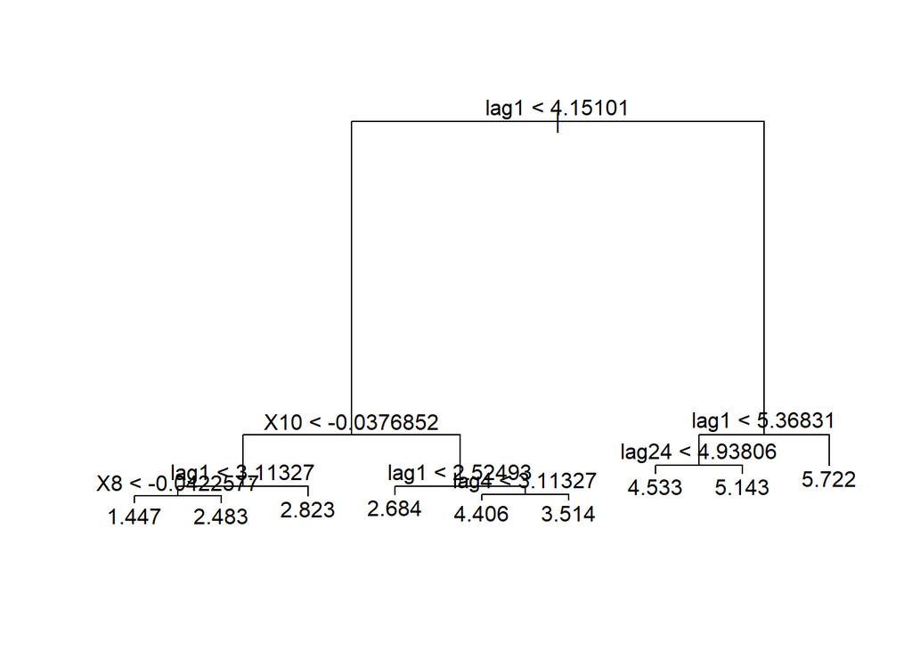

```r
plot(tree_model)
text(tree_model, pretty = 0)
```

### Problem 4.6

Add the predictions from Problem 4.4 to the figure you created in Problem 4.3. Comment on the fit of the regression tree compared to that of the semi-parametric spline approach.

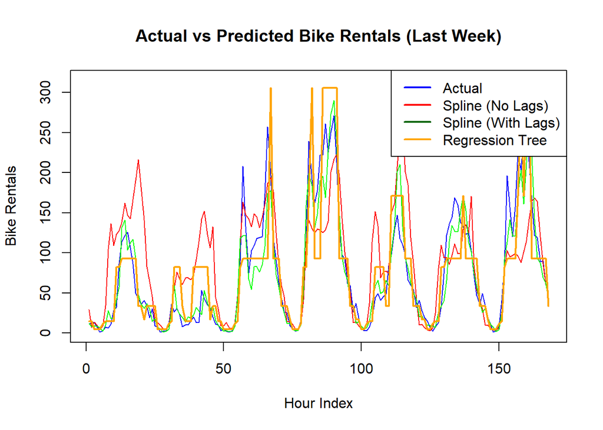

```r
# COPY FROM 4.3
last_week_plot <- plot(last_week_data$cnt, type = "l", col = "blue", lwd = 1,
     ylab = "Bike Rentals", xlab = "Hour Index", main = "Actual vs Predicted Bike Rentals (Last Week)")
lines(y_hat_cnt, col = "red", lwd = 1)

# Add to existing plot
lines(y_hat_cnt_4.2, col = "green", lwd = 1)
# END OF COPY FROM 4.3

# Convert y_hat_tree_test from log_cnt to cnt
y_hat_tree_cnt <- exp(tail(y_hat_tree_test, n = 168))


lines(y_hat_tree_cnt, col = "orange", lwd = 2)       # Regression tree (Problem 4.4)

legend("topright", legend = c("Actual", "Spline (No Lags)", "Spline (With Lags)", "Regression Tree"),
       col = c("blue", "red", "darkgreen", "orange"), lty = 1, lwd = 2)
```

## 5. Logistic regression and decision trees for classifying spam emails

The dataset `spam_ham_emails.RData` consists of $n=4601$ spam ($y=1$) and ham (no spam, $y=0$) emails with corresponding 15 features[^2].

Most of the features are continuous real variables in the interval $[0, 100]$, with values corresponding to the percentage of occurrence of a specific word or character in the email. There are also a few features that capture the tendency to use many capital letters. The features are on different scales so we will standardise them to have zero mean and unit variance. The following code reads in the data (note that you have to change to the path were you stored the file!), standardises the features, and codes the response variable as a factor.

```r
rm(list=ls()) # Remove variables
cat("\014") # Clean workspace
```

```r
load(file = 'C:/Users/asus/Desktop/Machine learning/Lab 1/spam_ham_emails.RData')
Spam_ham_emails[, -1] <- scale(Spam_ham_emails[, -1]) # choose all columns except the first, standardise them
Spam_ham_emails['spam'] <- as.factor(Spam_ham_emails['spam'] == 1) # Changing from 1->TRUE, 0->FALSE # as.factor summarizes all categories and and their frequencies # logistic regression works well with factors
levels(Spam_ham_emails$spam) <- c("not spam", "spam") # change the name of levels from FALSE/TRUE by default to "not spam", "spam"
head(Spam_ham_emails)
```

```
      spam       over     remove   internet        free        hpl          X.
1 not spam -0.3502281 -0.2917622 -0.2625330 -0.30134485  4.2669752 -0.32987644
2     spam  1.6583607 -0.2917622  0.4106637  1.03071019 -0.2992074  0.38364598
3 not spam -0.3502281 -0.2917622 -0.2625330 -0.30134485  2.6659926 -0.32987644
4     spam  0.6358064 -0.2917622 -0.2625330 -0.30134485 -0.2992074 -0.28451505
5     spam  0.3436480  0.1936234 -0.2625330 -0.07126262 -0.2992074 -0.06996793
6     spam -0.3502281  0.9855684  0.9841276 -0.30134485 -0.2992074  0.17522878
        X..1   CapRunMax CapRunTotal        our         hp   george      X1999
1 -0.3083214 -0.17021174  0.02096274 -0.4642639  3.9791176 -0.22787  4.9900587
2  0.8751730 -0.08811470  0.01271665 -0.4642639 -0.3287789 -0.22787 -0.3234205
3 -0.3083214 -0.22665345 -0.40618481 -0.4642639 -0.3287789 -0.22787  2.7702052
4 -0.3083214 -0.09837683 -0.12416847 -0.4642639 -0.3287789 -0.22787 -0.3234205
5  0.9239769  0.40959862  0.75651413 -0.1817414 -0.3287789 -0.22787 -0.3234205
6  1.3672790 -0.17021174 -0.05655052  0.6658261 -0.3287789 -0.22787 -0.3234205
           re       edu
1  0.59185916 -0.197366
2 -0.03086294 -0.197366
3 -0.29774385 -0.197366
4 -0.29774385 -0.197366
5 -0.29774385 -0.197366
6 -0.29774385 -0.197366
```

```r
str(Spam_ham_emails)
```

```
'data.frame':   4601 obs. of  16 variables:
 $ spam       : Factor w/ 2 levels "not spam","spam": 1 2 1 2 2 2 2 1 2 1 ...
 $ over       : num  -0.35 1.658 -0.35 0.636 0.344 ...
 $ remove     : num  -0.292 -0.292 -0.292 -0.292 0.194 ...
 $ internet   : num  -0.263 0.411 -0.263 -0.263 -0.263 ...
 $ free       : num  -0.3013 1.0307 -0.3013 -0.3013 -0.0713 ...
 $ hpl        : num  4.267 -0.299 2.666 -0.299 -0.299 ...
 $ X.         : num  -0.33 0.384 -0.33 -0.285 -0.07 ...
 $ X..1       : num  -0.308 0.875 -0.308 -0.308 0.924 ...
 $ CapRunMax  : num  -0.1702 -0.0881 -0.2267 -0.0984 0.4096 ...
 $ CapRunTotal: num  0.021 0.0127 -0.4062 -0.1242 0.7565 ...
 $ our        : num  -0.464 -0.464 -0.464 -0.464 -0.182 ...
 $ hp         : num  3.979 -0.329 -0.329 -0.329 -0.329 ...
 $ george     : num  -0.228 -0.228 -0.228 -0.228 -0.228 ...
 $ X1999      : num  4.99 -0.323 2.77 -0.323 -0.323 ...
 $ re         : num  0.5919 -0.0309 -0.2977 -0.2977 -0.2977 ...
 $ edu        : num  -0.197 -0.197 -0.197 -0.197 -0.197 ...
```

The response is the first column `spam` and we will use all the other features to predict if an email is a spam or ham. Let us first inspect the fraction of spam emails in the dataset.

```r
cat("Percentage of spam:", 100*mean(Spam_ham_emails$spam == "spam"))
```

```
Percentage of spam: 39.40448
```

We now split the data using the `createDataPartition()` function in the `caret` package. The default method in `caret` is stratified sampling, which keeps the same fraction of spam and ham in both the training and test datasets. We use 75% of the data for training and 25% for testing.

```r
set.seed(1234)
suppressMessages(library(caret))
train_obs <- createDataPartition(y = Spam_ham_emails$spam, p = .75, list = FALSE)
# split data into train and test, y =... preserves the class distribution (spam/not spam), p =... is the ratio of training set
train <- Spam_ham_emails[train_obs, ] # assign data to the set, train_obs = train data, - train_obs = test data
test <- Spam_ham_emails[-train_obs, ]
# Confirm both training and test are balanced with respect to spam emails
cat("Percentage of training data consisting of spam emails:",
              100*mean(train$spam == "spam"), "\n")
```

```
Percentage of training data consisting of spam emails: 39.40887
```

```r
cat("Percentage of test data consisting of spam emails:",
              100*mean(test$spam == "spam"))
```

```
Percentage of test data consisting of spam emails: 39.3913
```

The following code fits a logistic regression on the training data using the `glm()` function, predicts the test data following the rule if $\mathrm{Pr}(y=1|\mathbf{x})>0.5 \Rightarrow y=1$, and computes the confusion matrix using the `caret` package.

```r
glm_fit <- glm(spam ~ ., family = binomial, data = train) # Fits a logistic regression model using the training data
y_prob_hat_test <- predict(glm_fit, newdata = test, type = "response") # Uses the trained logistic model (glm_fit) to predict probabilities of being "spam" on the test set
threshold <- 0.5 # Predict spam if probability > threshold # Emails with predicted probability > 0.5 are classified as "spam", otherwise "not spam".
y_hat_test <- as.factor(y_prob_hat_test > threshold) # Converts predicted probabilities to class labels: TRUE becomes 1 (later "spam"), FALSE becomes 0 (later "not spam")
levels(y_hat_test) <- c("not spam", "spam") # Renames the factor levels from default "FALSE"/"TRUE" to "not spam"/"spam" to ensure consistency with test$spam, which uses those labels.
confusionMatrix(data = y_hat_test, test$spam, positive = "spam") # Generates a confusion matrix comparing: data = y_hat_test: your model’s predicted class labels, reference = test$spam: the actual class labels, positive = "spam" specifies that "spam" is the class of interest (important for precision, recall, F1 score, etc.).
```

```
Confusion Matrix and Statistics

          Reference
Prediction not spam spam
  not spam      658   65
  spam           39  388

               Accuracy : 0.9096
                 95% CI : (0.8915, 0.9255)
    No Information Rate : 0.6061
    P-Value [Acc > NIR] : < 2e-16

                  Kappa : 0.8087

 Mcnemar's Test P-Value : 0.01423

            Sensitivity : 0.8565
            Specificity : 0.9440
         Pos Pred Value : 0.9087
         Neg Pred Value : 0.9101
             Prevalence : 0.3939
         Detection Rate : 0.3374
   Detection Prevalence : 0.3713
      Balanced Accuracy : 0.9003

       'Positive' Class : spam
```

### Problem 5.1

Reconstruct the confusion matrix for the test data without using the `confusionMatrix()` function.

We can use table() to create a confusion matrix manually

```r
manual_confusion_matrix <- table(Predicted = y_hat_test, Actual = test$spam)
print(manual_confusion_matrix)
```

```
          Actual
Predicted  not spam spam
  not spam      658   65
  spam           39  388
```

### Problem 5.2

Compute the accuracy, precision, sensitivity (recall), and specificity without using the `confusionMatrix()` function. Explain these four concepts in the context of the spam filter.

```r
# extract values from confusion matrix
TP <- manual_confusion_matrix["spam", "spam"]
TN <- manual_confusion_matrix["not spam", "not spam"]
FP <- manual_confusion_matrix["spam", "not spam"]
FN <- manual_confusion_matrix["not spam", "spam"]
cat(" TP", TP, "\n","TN", TN, "\n","FP", FP, "\n","FN", FN)
```

```
 TP 388
 TN 658
 FP 39
 FN 65
```

```r
accuracy <- (TP+TN)/(TP+TN+FP+FN)
cat("accuracy", accuracy, "\n")
```

```
accuracy 0.9095652
```

```r
precision <- TP/(TP + FP)
cat("precision", precision, "\n")
```

```
precision 0.9086651
```

```r
sensitivity <- TP/(TP + FN)
cat("sensitivity", sensitivity, "\n")
```

```
sensitivity 0.8565121
```

```r
specificity <- TN/(TN + FP)
cat("specificity", specificity, "\n")
```

```
specificity 0.9440459
```

Accuracy = 0.9095652: overall, the model can detect spam emails correctly 90% of the times

Precision = 0.9086651: 90% of the emails that the model classifies as spam is indeed spam

Sensitivity = 0.8565121: 85% of the spam emails are successfully detected

Specificity = 0.9440459: the model can detect not spam emails correctly 94% of the times

### Problem 5.3

Compute the receiver operating characteristic (ROC) curve using the `pROC`. Explain in detail what the ROC curve shows.

```r
suppressMessages(library(pROC))
```

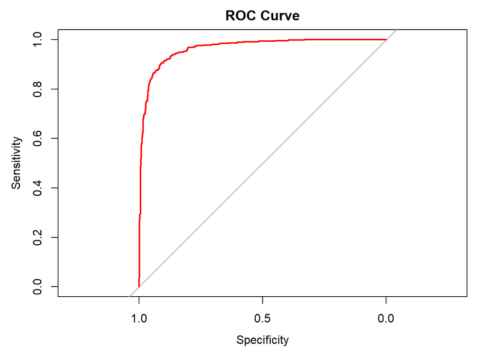

```r
# Plot ROC curve
roc_curve <- roc(response = test$spam,
               predictor = y_prob_hat_test,
               levels = c("not spam", "spam"),
               direction = "<")
plot(roc_curve, col = "red", lwd = 2, main = "ROC Curve")
```

```r
# Find best threshold and AUC as input for my comment below
cat("AUC", auc(roc_curve), "\n")
```

```
AUC 0.9650901
```

```r
best_threshold <- coords(roc_curve, x = "best", best.method = "youden", transpose = FALSE)
print(best_threshold)
```

```
  threshold specificity sensitivity
1 0.3979249   0.9124821   0.9028698
```

With AUC = 0.9650901, close to 1, we can conclude that using logistic regression method perform well in separating spam and not spam emails.

### Problem 5.4

Using the training dataset, fit a decision tree (classification tree) using the `tree` package with the default settings. How does this classifier perform on the test dataset compared to the logistic classifier?

```r
suppressMessages(library(tree))

# Fit a decision tree on train data
tree_5.4 <- tree(spam ~ ., data = train)
```

```r
# Predict class labels on the test data
tree_5.4_test <- predict(tree_5.4, newdata = test, type = "class")

# Ensure factor levels match for comparison
tree_5.4_test <- factor(tree_5.4_test, levels = c("not spam", "spam"))

suppressMessages(library(caret))
confusionMatrix(data = tree_5.4_test, test$spam, positive = "spam")
```

```
Confusion Matrix and Statistics

          Reference
Prediction not spam spam
  not spam      652   66
  spam           45  387

               Accuracy : 0.9035
                 95% CI : (0.8849, 0.9199)
    No Information Rate : 0.6061
    P-Value [Acc > NIR] : < 2e-16

                  Kappa : 0.7962

 Mcnemar's Test P-Value : 0.05765

            Sensitivity : 0.8543
            Specificity : 0.9354
         Pos Pred Value : 0.8958
         Neg Pred Value : 0.9081
             Prevalence : 0.3939
         Detection Rate : 0.3365
   Detection Prevalence : 0.3757
      Balanced Accuracy : 0.8949

       'Positive' Class : spam
```

```
Logistic model
sensitivity 0.8565121  specificity 0.9440459 accuracy 0.9096
Tree model
sensitivity 0.8543     specificity 0.9354    accuracy 0.9035
```

From the confusion matrix of the logistic model and tree model, the logistic model performs better in all criteria.

### Problem 5.5

Plot the tree structure in Problem 5.4.

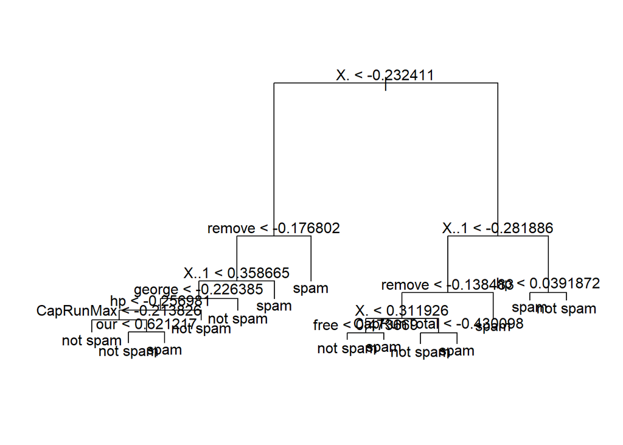

```r
suppressMessages(library(tree))
# Plot the tree structure
plot(tree_5.4)
text(tree_5.4, pretty = 0)
```

## Footnotes

[^1]: The original data come from this [source](https://archive.ics.uci.edu/dataset/275/bike+sharing+dataset).
[^2]: The original data come from this [source](https://archive.ics.uci.edu/ml/datasets/spambase). The dataset used here includes a subset of the 57 original features.